# nmer_FinalHomeworkCode_04

Nicole Merullo

2023-10-31

# Homework 4 What’s Your Malfunction?

[figure not shown]

##Challenges 1. Telling the formula to do a one sample z test with p2 and n2 as null. I was getting a warning that I needed to use is.null but I thought I still needed to put that after the == for each object. After searching around, I realized it was kind of its own function.  
2. Could not figure out how to get the conf.level to vary in the CI part of the formula. Found a way to do this in Module 7. I double checked this worked and what I had for my formula using the Module 10 Challenge 4 example data for a one sample proportion z test.  
3. Figuring out the CI for the two sample proportation test was tricky. I used a test from Challenge 5 in Module 10 and broke it down by each component to make sure the formula was working at each part: z statistic, p value, etc. My CI were not quite working out because I tried replacing instances of p1 with p2-p1 from the one sample. Instead, I defined SE for clarity and used pstar. This got me the right values that the Module 10 Challenge 5 answers has.  
4. I could not figure out the legends on the plots in question 2. I read a lot of the documentation and used the tidyverse textbook and eventually moved my parentheses to include the color argument inside the aes() mapping and then instead of using actual colors inside I used strings and then referenced those strings in scale_color_manual(values = c(“fit” = “black”,“CI” = “blue”,“PI” = “red”)) where I defined the colors. 5. Sometimes the point estimate worked and other times it did not for the last part of question 2. When I plugged in the brain size into predict, copying right from module 12 challenge 4 where we predicted prediction intervals for a single vector, sometimes it would give me a single point estimate and associate CI and other times it would give me 26! I can’t find a difference between the two instances but I am sure I am missing it. Additionally, I was not sure if I should use beta1 * 800 + beta0 or predict() set to a single vector, so I did both but these got different point estimates.

## Z.prop.test

-Your function should take the following arguments: p1 and n1 (no default) representing the estimated proportion and sample size (i.e., based on your sample data); p2 and n2 (both defaulting to NULL) that contain a second sample’s proportion and sample size data in the event of a two-sample test; p0 (no default) as the expected value for the population proportion; and alternative (default “two.sided”) and conf.level (default 0.95), to be used in the same way as in the function t.test().  
-When conducting a two-sample test, it should be p1 that is tested as being smaller or larger than p2 when alternative=“less” or alternative=“greater”, the same as in the use of x and y in the function t.test().  
-The function should perform a one-sample Z-test using p1, n1, and p0 if either p2 or n2 (or both) is NULL.  
-The function should contain a check for the rules of thumb we have talked about (n∗p>5 and n∗(1−p)>5) to ensure the validity of assuming the normal distribution in both the one- and two-sample settings. If this is violated, the function should still complete but it should also print an appropriate warning message.  
-The function should return a list containing the members Z (the test statistic), P (the appropriate p value), and CI (the two-sided CI with respect to “conf.level” around p1 in the case of a one-sample test and around p2-p1 in the case of a two-sample test). For all test alternatives (“two.sided”, “greater”, “less”), calculate symmetric CIs based on quantiles of the normal distribution rather than worrying about calculating single-limit confidence bounds.

```r
Z.prop.test <- function(p0, p1, n1, p2 = NULL, n2 = NULL, alternative = "two.sided", conf.level = 0.95) {}
```

**Peer Comment: I really like how you structured your function. Looks very organized.

```r
Z.prop.test <- function(p0, p1, n1, p2 = NULL, n2 = NULL, alternative = "two.sided", conf.level = 0.95)
{
 if (is.null(p2) | is.null(n2)) {
   z <- (p1 - p0)/sqrt(p0*(1 - p0) / n1) #one sample z test
   if (alternative == "greater") {p <- pnorm(z, lower.tail = FALSE)}
   if (alternative == "less") {p <- pnorm(z, lower.tail = TRUE)}
   if (alternative == "two.sided") {
            if (z > 0)
                {
                p <- 2 * pnorm(z, lower.tail = FALSE)
                }
            if (z < 0)
                {
                p <- 2 * pnorm(z, lower.tail = TRUE)
            }} #taking the p value with respect to the left tail or the right tail
  upper <- p1 + qnorm(1 - (1 - conf.level)/2) * sqrt(p1 * (1 - p1)/n1)
  lower <- p1 + qnorm((1 - conf.level)/2) * sqrt(p1 * (1 - p1)/n1)
  ci <- c(lower, upper) }
  return(c(z,p, ci))
}
```

```r
Z.prop.test(p0 = 0.8, p1 = 0.6, n1 = 30, alternative = "less")
```

```
## [1] -2.73861279  0.00308495  0.42469549  0.77530451
```

```r
Z.prop.test <- function(p0, p1, n1, p2 = NULL, n2 = NULL, alternative = "two.sided", conf.level = 0.95)
{
 if (is.null(p2) | is.null(n2)) {
   z <- (p1 - p0)/sqrt(p0*(1 - p0) / n1) #one sample z test
   if (alternative == "greater") {p <- pnorm(z, lower.tail = FALSE)}
   if (alternative == "less") {p <- pnorm(z, lower.tail = TRUE)}
   if (alternative == "two.sided") {
            if (z > 0)
                {
                p <- 2 * pnorm(z, lower.tail = FALSE)
                }
            if (z < 0)
                {
                p <- 2 * pnorm(z, lower.tail = TRUE)
            }} #Adapted from Module 11
  upper <- p1 + qnorm(1 - (1 - conf.level)/2) * sqrt(p1 * (1 - p1)/n1)
  lower <- p1 + qnorm((1 - conf.level)/2) * sqrt(p1 * (1 - p1)/n1)
  ci <- c(lower, upper) }
 else {
   pstar <- (p1+p2)/2 #simplification of the pstar equation from module 10
   z <- (p2 - p1 - p0)/sqrt((pstar * (1 - pstar)) * (1/n1 + 1/n2))
    if (alternative == "greater") {p <- pnorm(z, lower.tail = FALSE)}
    if (alternative == "less") {p <- pnorm(z, lower.tail = TRUE)}
    if (alternative == "two.sided") {p <- 1 - pnorm(z, lower.tail = TRUE) + pnorm(z, lower.tail = FALSE)} #adapted from module 10
   se <- sqrt(pstar * (1-pstar) * (1/n1 + 1/n2))
   upper <- (p2-p1) + qnorm(1 - (1 - conf.level)/2) * se
   lower <- (p2-p1) + qnorm((1 - conf.level)/2) * se
   ci <- c(lower, upper)
 }
  return(c(z,p, ci))
}
```

```r
v1 <- c(1, 0, 1, 1, 0, 0, 1, 1, 0, 0, 1, 1, 1, 1, 0, 0, 1, 1, 0, 0, 1, 1, 0,
    1, 0)
n1 <- length(v1)
v2 <- c(1, 1, 0, 0, 1, 1, 1, 1, 0, 1, 0, 1, 1, 1, 0, 1, 0, 1, 1, 1, 1, 1, 0,
    0, 1, 1, 0, 1, 1, 1)
n2 = length(v2)
Z.prop.test(p0=0, p1=mean(v1), p2=mean(v2), n1=n1, n2=n2)
```

```
## [1]  1.0707946  0.2842618 -0.1162536  0.3962536
```

```r
Z.prop.test <- function(p0, p1, n1, p2 = NULL, n2 = NULL, alternative = "two.sided", conf.level = 0.95)
{
 if (is.null(p2) | is.null(n2)) {
   if ( (n1 * p1) < 5 | (n1 * (1 - p1)) < 5 )
  {print("Warning: This test violates the expectation based on the approximation of the normal")}
   z <- (p1 - p0)/sqrt(p0*(1 - p0) / n1) #one sample z test
   if (alternative == "greater") {p <- pnorm(z, lower.tail = FALSE)}
   if (alternative == "less") {p <- pnorm(z, lower.tail = TRUE)}
   if (alternative == "two.sided") {
            if (z > 0)
                {
                p <- 2 * pnorm(z, lower.tail = FALSE)
                }
            if (z < 0)
                {
                p <- 2 * pnorm(z, lower.tail = TRUE)
            }} #Adapted from Module 11
  upper <- p1 + qnorm(1 - (1 - conf.level)/2) * sqrt(p1 * (1 - p1)/n1)
  lower <- p1 + qnorm((1 - conf.level)/2) * sqrt(p1 * (1 - p1)/n1)
  ci <- c(lower, upper) }
 else { if ((n2 * p2) < 5 | (n2 * (1 - p2)) < 5)
  {print("Warning: This test violates the expectation based on the approximation of the normal")}
   pstar <- (p1+p2)/2 #simplification of the pstar equation from module 10
   z <- (p2 - p1 - p0)/sqrt((pstar * (1 - pstar)) * (1/n1 + 1/n2))
    if (alternative == "greater") {p <- pnorm(z, lower.tail = FALSE)}
    if (alternative == "less") {p <- pnorm(z, lower.tail = TRUE)}
    if (alternative == "two.sided") {p <- 1 - pnorm(z, lower.tail = TRUE) + pnorm(z, lower.tail = FALSE)} #adapted from module 10
   se <- sqrt(pstar * (1-pstar) * (1/n1 + 1/n2))
   upper <- (p2-p1) + qnorm(1 - (1 - conf.level)/2) * se
   lower <- (p2-p1) + qnorm((1 - conf.level)/2) * se
   ci <- c(lower, upper)
 }
  return(list("z" = z, "p" = p, "confidence intervals" = ci))
  }
```

**Note: changed return to list instead of vector after seeing Jess’ version, and liking the way it printed so that results were labeled**

```r
Z.prop.test(p0 = 0.8, p1 = 0.6, n1 = 5, alternative = "less")
```

```
## [1] "Warning: This test violates the expectation based on the approximation of the normal"
```

```
## $z
## [1] -1.118034
##
## $p
## [1] 0.1317762
##
## $`confidence intervals`
## [1] 0.1705934 1.0294066
```

```r
Z.prop.test(p0=0, p1=0.66, n1=3, p2=0.75, n2=4, alternative = "greater")
```

```
## [1] "Warning: This test violates the expectation based on the approximation of the normal"
```

```
## $z
## [1] 0.2583917
##
## $p
## [1] 0.3980523
##
## $`confidence intervals`
## [1] -0.5926719  0.7726719
```

## Kamilar and Cooper Data

The dataset from Kamilar and Cooper has in it a large number of variables related to life history and body size. For this exercise, the end aim is to fit a simple linear regression model to predict longevity (MaxLongevity_m) measured in months from species’ brain size (Brain_Size_Species_Mean) measured in grams. Do the following for both longevity~brain size and log(longevity)~log(brain size):

Fit the regression model and, using {ggplot2}, produce a scatterplot with the fitted line superimposed upon the data. Append the the fitted model equation to your plot (HINT: use the function geom_text()).

```r
file <- curl("https://raw.githubusercontent.com/fuzzyatelin/fuzzyatelin.github.io/master/AN588_Fall23/KamilarAndCooperData.csv")
d <- read.csv(file, header= TRUE, sep = ",", stringsAsFactors = FALSE)
head(d)
```

```
##               Scientific_Name          Family          Genus      Species
## 1 Allenopithecus_nigroviridis Cercopithecidae Allenopithecus nigroviridis
## 2         Allocebus_trichotis Cercopithecidae      Allocebus    trichotis
## 3           Alouatta_belzebul        Atelidae       Alouatta     belzebul
## 4             Alouatta_caraya        Atelidae       Alouatta       caraya
## 5            Alouatta_guariba        Atelidae       Alouatta      guariba
## 6           Alouatta_palliata        Atelidae       Alouatta     palliata
##   Brain_Size_Species_Mean Brain_Size_Female_Mean   Brain_size_Ref
## 1                   58.02                  53.70 Isler et al 2008
## 2                      NA                     NA
## 3                   52.84                  51.19 Isler et al 2008
## 4                   52.63                  47.80 Isler et al 2008
## 5                   51.70                  49.08 Isler et al 2008
## 6                   49.88                  48.04 Isler et al 2008
##   Body_mass_male_mean Body_mass_female_mean Mass_Dimorphism
```

[output cut: 62 more lines]

Fitting the models

**Peer Comment: This was an interesting way to do it. Setting up the variables like this might have solved a few future problems for me. To calculate the longevity & brain size model I did mod1 <- lm(MaxLongevity_m ~ Brain_Size_Species_Mean, data = d) and then plotted that with text.

```r
d <- na.omit(d)
l <- d$MaxLongevity_m
b <- d$Brain_Size_Species_Mean
LOGl <-log(d$MaxLongevity_m)
LOGb <- log(d$Brain_Size_Species_Mean)
m <- lm(data = d, l~b)
summary(m)
```

```
##
## Call:
## lm(formula = l ~ b, data = d)
##
## Residuals:
##      Min       1Q   Median       3Q      Max
## -152.498  -73.422   -4.425   72.430  285.749
##
## Coefficients:
##             Estimate Std. Error t value Pr(>|t|)
## (Intercept) 307.7522    27.8459  11.052 6.73e-11 ***
## b             0.8789     0.1672   5.256 2.18e-05 ***
## ---
## Signif. codes:  0 '***' 0.001 '**' 0.01 '*' 0.05 '.' 0.1 ' ' 1
##
## Residual standard error: 98.31 on 24 degrees of freedom
## Multiple R-squared:  0.5351, Adjusted R-squared:  0.5158
## F-statistic: 27.63 on 1 and 24 DF,  p-value: 2.176e-05
```

```r
logm <- lm(data = d, LOGl~LOGb)
summary(logm)
```

```
##
## Call:
## lm(formula = LOGl ~ LOGb, data = d)
##
## Residuals:
##      Min       1Q   Median       3Q      Max
## -0.43044 -0.18029 -0.01211  0.17548  0.53196
##
## Coefficients:
##             Estimate Std. Error t value Pr(>|t|)
## (Intercept)  5.08650    0.22413  22.694  < 2e-16 ***
## LOGb         0.20285    0.05002   4.055 0.000458 ***
## ---
## Signif. codes:  0 '***' 0.001 '**' 0.01 '*' 0.05 '.' 0.1 ' ' 1
##
## Residual standard error: 0.2539 on 24 degrees of freedom
## Multiple R-squared:  0.4066, Adjusted R-squared:  0.3819
## F-statistic: 16.44 on 1 and 24 DF,  p-value: 0.0004583
```

Plotting **Peer Comments: I liked how you changed the color of the text. To calculate b1, I used the summary function and then isolated the coefficients. It doesn’t really matter but I wonder why you decided to graph the way you did. Why assign them each to p1 instead just write it all in the same line? If you’re interested in simplifying your code, I’d recommend establishing the models and then just calling them when you are developing your graphs.

```r
beta1 <- cor(l, b) * (sd(b)/sd(l))
beta1
```

```
## [1] 0.60885
```

```r
beta0 <- mean(l) - beta1 * mean(b)
beta0
```

```
## [1] 340.1996
```

```r
log.beta1 <- cor(LOGb, LOGl) * (sd(LOGb)/sd(LOGl))
log.beta1
```

```
## [1] 2.004351
```

```r
log.beta0 <- mean(LOGl) - log.beta1 * mean(LOGb)
log.beta0
```

```
## [1] -2.783441
```

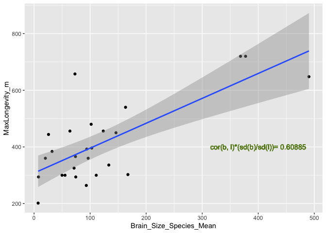

```r
par(mfrow = c(2,1))
p1 <- ggplot(data = d, aes(x = Brain_Size_Species_Mean, y = MaxLongevity_m)) +
  geom_point() +
  geom_smooth(method = "lm", formula = y ~ x) +
  geom_text(x = 400, y = 400, label = "cor(b, l)*(sd(b)/sd(l))= 0.60885", colour = "olivedrab4")
p1
```

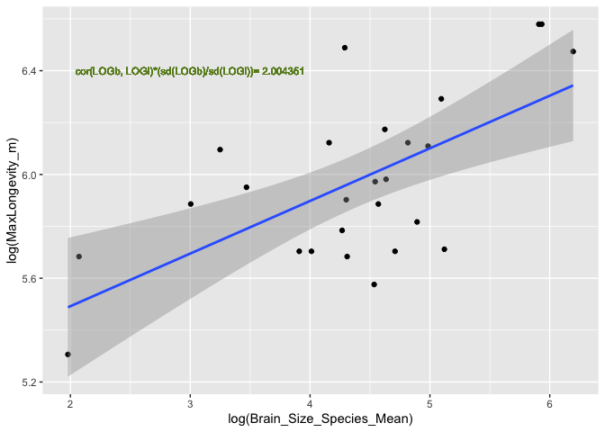

```r
pLog <- ggplot(data = d, aes(x = log(Brain_Size_Species_Mean), y = log(MaxLongevity_m))) +
  geom_point() +
  geom_smooth(method = "lm", formula = y ~ x) +
  geom_text(x = 3, y = 6.4, label = "cor(LOGb, LOGl)*(sd(LOGb)/sd(LOGl))= 2.004351", colour = "olivedrab4", size = 3)
pLog
```

Identify and interpret the point estimate of the slope (β1), as well as the outcome of the test associated with the hypotheses H0: β1 = 0; HA: β1 ≠ 0. Also, find a 90 percent CI for the slope (β1) parameter.

**Peer Commentary: While I understand why you broke your code up the way you did, it would be easier to read if you moved the code calculatign B1 down here.

```r
#non-transformed data
m <- lm(data = d, l ~ b) #fitting the model y~x
ci <- predict(m, newdata = data.frame(Brainsize = d$Brain_Size_Species_Mean), interval = "confidence", level = 0.90)  #predicting the 90% CI at the x values
head(ci)
```

```
##        fit      lwr      upr
## 1 351.5919 312.9621 390.2217
## 2 356.2853 318.4280 394.1425
## 3 314.1155 267.9467 360.2843
## 4 371.8507 336.2051 407.4962
## 5 370.4444 334.6229 406.2659
## 6 373.1339 337.6445 408.6232
```

```r
df <- data.frame(cbind(d$Brain_Size_Species_Mean, d$MaxLongevity_m, ci)) #binding the x and y axes with the fit, lower, and upper values from the predict function
head(df) #checking the number of columns
```

```
##      V1    V2      fit      lwr      upr
## 1 49.88 300.0 351.5919 312.9621 390.2217
## 2 55.22 300.0 356.2853 318.4280 394.1425
## 3  7.24 201.6 314.1155 267.9467 360.2843
## 4 72.93 657.6 371.8507 336.2051 407.4962
## 5 71.33 325.2 370.4444 334.6229 406.2659
## 6 74.39 294.0 373.1339 337.6445 408.6232
```

```r
names(df) <- c("x", "y", "CIfit", "CIlwr", "CIupr") #naming the columns
head(df)
```

```
##       x     y    CIfit    CIlwr    CIupr
## 1 49.88 300.0 351.5919 312.9621 390.2217
## 2 55.22 300.0 356.2853 318.4280 394.1425
## 3  7.24 201.6 314.1155 267.9467 360.2843
## 4 72.93 657.6 371.8507 336.2051 407.4962
## 5 71.33 325.2 370.4444 334.6229 406.2659
## 6 74.39 294.0 373.1339 337.6445 408.6232
```

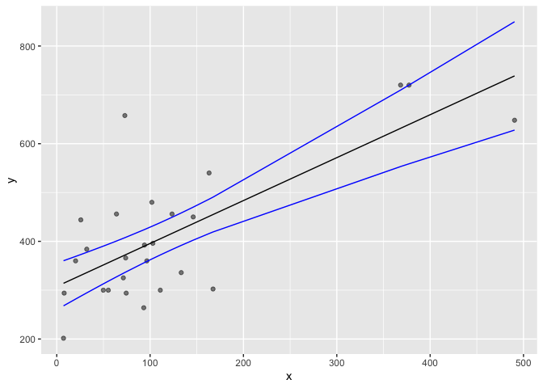

```r
g <- ggplot(data = df, aes(x = x, y = y)) + #plotting longevity (y) against brain size (x) but this time from the data frame I just made
  geom_point(alpha = 1/2) +
  geom_line(aes(x = x, y = CIfit), colour = "black") + #fitting the linear regression
  geom_line(aes(x = x, y = CIlwr), colour = "blue") + #fitting the lower CI line
  geom_line(aes(x = x, y = CIupr), colour = "blue") #fitting the upper CI line
g
```

```r
# log plot
logm <- lm(LOGl~LOGb) # fitting the model y~x
ci <- predict(logm, newdata = data.frame(BrainSize = LOGb), interval = "confidence", level = 0.90)  #predicting the 90% CI at the x values
head(ci)
```

```
##        fit      lwr      upr
## 1 5.879581 5.785763 5.973399
## 2 5.900212 5.809692 5.990732
## 3 5.488072 5.266574 5.709571
## 4 5.956641 5.871172 6.042110
## 5 5.952141 5.866501 6.037781
## 6 5.960662 5.875311 6.046013
```

```r
logdf <- data.frame(cbind(LOGb, LOGl, ci))
head(logdf)
```

```
##       LOGb     LOGl      fit      lwr      upr
## 1 3.909620 5.703782 5.879581 5.785763 5.973399
## 2 4.011325 5.703782 5.900212 5.809692 5.990732
## 3 1.979621 5.306286 5.488072 5.266574 5.709571
## 4 4.289500 6.488597 5.956641 5.871172 6.042110
## 5 4.267317 5.784440 5.952141 5.866501 6.037781
## 6 4.309322 5.683580 5.960662 5.875311 6.046013
```

```r
names(logdf) <- c("x", "y", "CIfit", "CIlwr", "CIupr")
head(logdf)
```

```
##          x        y    CIfit    CIlwr    CIupr
## 1 3.909620 5.703782 5.879581 5.785763 5.973399
## 2 4.011325 5.703782 5.900212 5.809692 5.990732
## 3 1.979621 5.306286 5.488072 5.266574 5.709571
## 4 4.289500 6.488597 5.956641 5.871172 6.042110
## 5 4.267317 5.784440 5.952141 5.866501 6.037781
## 6 4.309322 5.683580 5.960662 5.875311 6.046013
```

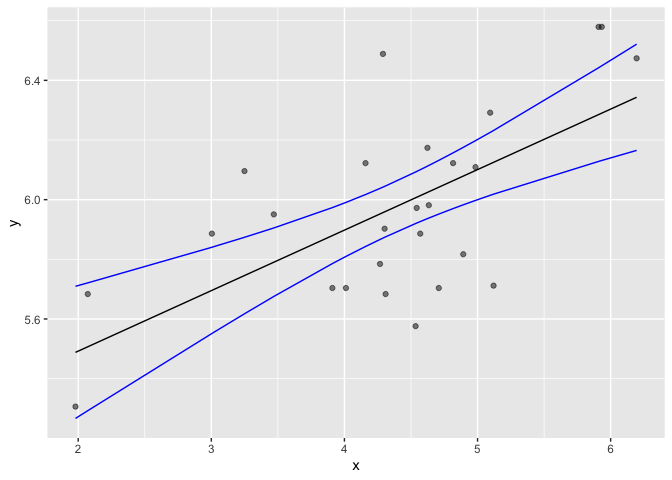

```r
logg <- ggplot(data = logdf, aes(x = x, y = y)) +
  geom_point(alpha = 1/2) +
  geom_line(aes(x = x, y = CIfit), colour = "black") +
  geom_line(aes(x = x, y = CIlwr), colour = "blue") +
  geom_line(aes(x = x, y = CIupr), colour = "blue")
logg
```

Using your model, add lines for the 90 percent confidence and prediction interval bands on the plot and add a legend to differentiate between the lines.

```r
#non-transformed data
pi <- predict(m, newdata = data.frame(Brainsize = d$Brain_Size_Species_Mean), interval = "prediction",
    level = 0.90)  # for a vector of values
head(pi)
```

```
##        fit      lwr      upr
## 1 351.5919 179.0151 524.1688
## 2 356.2853 183.8797 528.6908
## 3 314.1155 139.6963 488.5347
## 4 371.8507 199.9172 543.7841
## 5 370.4444 198.4744 542.4144
## 6 373.1339 201.2328 545.0350
```

```r
dfpi <- cbind(df, pi)
names(dfpi) <- c("x", "y", "CIfit", "CIlwr", "CIupr", "PIfit", "PIlwr", "PIupr")
head(dfpi)
```

```
##       x     y    CIfit    CIlwr    CIupr    PIfit    PIlwr    PIupr
## 1 49.88 300.0 351.5919 312.9621 390.2217 351.5919 179.0151 524.1688
## 2 55.22 300.0 356.2853 318.4280 394.1425 356.2853 183.8797 528.6908
## 3  7.24 201.6 314.1155 267.9467 360.2843 314.1155 139.6963 488.5347
## 4 72.93 657.6 371.8507 336.2051 407.4962 371.8507 199.9172 543.7841
## 5 71.33 325.2 370.4444 334.6229 406.2659 370.4444 198.4744 542.4144
## 6 74.39 294.0 373.1339 337.6445 408.6232 373.1339 201.2328 545.0350
```

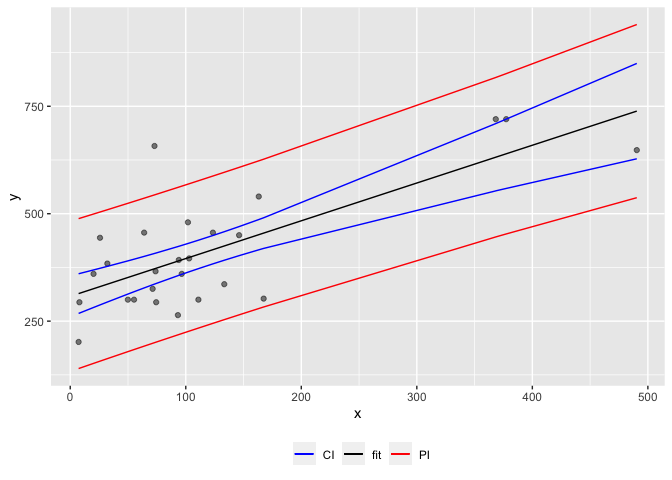

```r
g <- ggplot(data = dfpi, aes(x = x, y = y)) #pasted in ggplot code from above but changed data frame it is pulling from
g <- g + geom_point(alpha = 1/2) +
  geom_line(aes(x = x, y = CIfit, colour = "fit")) +
  geom_line(aes(x = x, y = CIlwr, colour = "CI")) +
  geom_line(aes(x = x, y = CIupr, colour = "CI")) +
  geom_line(aes(x = x, y = PIlwr, colour = "PI")) +
  geom_line(aes(x = x, y = PIupr, colour = "PI")) +
  scale_color_manual(values = c("fit" = "black","CI" = "blue","PI" = "red")) +
  theme(legend.position = "bottom", legend.title = element_blank())
g
```

```r
# log plot
pi <- predict(logm, newdata = data.frame(BrainSize = LOGb), interval = "prediction", level = 0.90)
head(pi)
```

```
##        fit      lwr      upr
## 1 5.879581 5.435127 6.324035
## 2 5.900212 5.456443 6.343982
## 3 5.488072 5.000426 5.975719
## 4 5.956641 5.513874 6.399408
## 5 5.952141 5.509341 6.394941
## 6 5.960662 5.517918 6.403406
```

```r
logdfpi <- cbind(logdf, pi)
names(logdfpi) <- c("x", "y", "CIfit", "CIlwr", "CIupr", "PIfit", "PIlwr", "PIupr")
head(logdfpi)
```

```
##          x        y    CIfit    CIlwr    CIupr    PIfit    PIlwr    PIupr
## 1 3.909620 5.703782 5.879581 5.785763 5.973399 5.879581 5.435127 6.324035
## 2 4.011325 5.703782 5.900212 5.809692 5.990732 5.900212 5.456443 6.343982
## 3 1.979621 5.306286 5.488072 5.266574 5.709571 5.488072 5.000426 5.975719
## 4 4.289500 6.488597 5.956641 5.871172 6.042110 5.956641 5.513874 6.399408
## 5 4.267317 5.784440 5.952141 5.866501 6.037781 5.952141 5.509341 6.394941
## 6 4.309322 5.683580 5.960662 5.875311 6.046013 5.960662 5.517918 6.403406
```

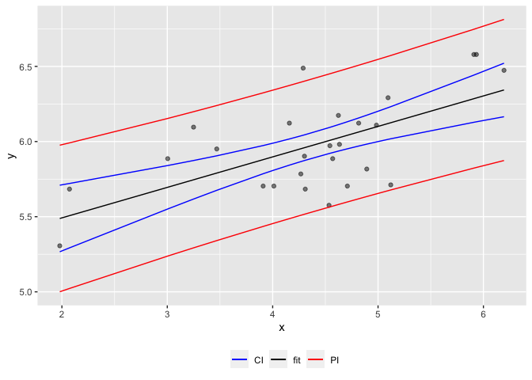

```r
logg <- ggplot(data = logdfpi, aes(x = x, y = y)) +
  geom_point(alpha = 1/2) +
  geom_line(aes(x = x, y = CIfit, colour = "fit")) +
  geom_line(aes(x = x, y = CIlwr, colour = "CI")) +
  geom_line(aes(x = x, y = CIupr, colour = "CI")) +
  geom_line(aes(x = x, y = PIlwr, colour = "PI")) +
  geom_line(aes(x = x, y = PIupr, colour = "PI")) +
  scale_color_manual(values = c("fit" = "black","CI" = "blue","PI" = "red")) +
  theme(legend.position = "bottom", legend.title = element_blank())
logg
```

Produce a point estimate and associated 90 percent PI for the longevity of a species whose brain weight is 800 gm. Do you trust the model to predict observations accurately for this value of the explanatory variable? Why or why not?

**Peer Commentary: I did this section differently so I’m unsure of exactly what prevents you from finding the point estimate. In office hours, Prof. Schmitt and I used this… the mod1 and mod2 are the regression models…

pi1 <- predict(mod1, newdata = data.frame(Brain_Size_Species_Mean = 800), interval = “prediction”, level = 0.90) pi1

and

pi2 <- predict(mod2, newdata = data.frame(Brain_Size_Species_Mean = 800), interval = “prediction”, level = 0.90) pi2

```r
longlife.est <- beta1 * 800 + beta0
longlife.est
```

```
## [1] 827.2796
```

```r
longlife.pi <- predict(m, newdata = data.frame(b = 800), interval = "prediction",
    level = 0.90)
longlife.pi
```

```
##        fit     lwr      upr
## 1 1010.875 751.631 1270.119
```

```r
log.longlife.est <- log.beta1 * log(800) + log.beta0
log.longlife.est
```

```
## [1] 10.61487
```

```r
log.longlife.pi <- predict(logm, newdata = data.frame(LOGb = log(800)), interval = "prediction", level = 0.90)
log.longlife.pi
```

```
##      fit      lwr      upr
## 1 6.4425 5.957435 6.927564
```

Looking at your two models, which do you think is better? Why?

I think the log transformed one is better because the data cloud is more spread out and the tightness in the CI lines are more in the middle (mean).

**Peer Commentary: your code is really well done! I can see the thought process behind all of your functions and I liked how you showed the calculations as you worked down. I would recommend formatting and attempting to simplify your code by using connectors but otherwise well done. Sorry I couldn’t offer more help on the point estimate value. From my understanding, this could mean the data you’re passing in for m needs to be re-established/is associated with something you don’t want.

**Final note: This was exactly it- I was passing m instead of logm as my first argument. UGH! Copy and paste did me dirty.**